# Cherry Blossom Race: Case Study

### Runners with age of zero

#### We finally get to a workable and cleaned dataset to use for analysis

```r
# we see 23 runners with an age of 0
count(allWomen[allWomen$age == 0, ])
```

```
## # A tibble: 1 x 1
##       n
##   <int>
## 1    23
```

```r
# removing rows with 0 / NA's in age column
allWomen <- allWomen[allWomen$age != 0, ]

# summary stats for womens age
allWomen %>% group_by(year) %>% summarise(ag_mean = mean(age, na.rm = T),
                                          ag_max = max(age, na.rm = T),
                                          ag_min = min(age, na.rm = T),
                                          ag_median = median(age, na.rm = T),
                                          ag_sd = sd(age, na.rm = T))
```

```
## # A tibble: 14 x 6
##     year ag_mean ag_max ag_min ag_median ag_sd
##    <int>   <dbl>  <dbl>  <dbl>     <dbl> <dbl>
##  1  1999    34.9     81     12        33  8.93
##  2  2000    35.6     76     14        34  9.32
##  3  2001    34.8     83     11        33  9.18
##  4  2002    35.1     84     13        33  9.23
##  5  2003    35.1     85     12        33  9.37
##  6  2004    33.9     86     13        32  9.29
##  7  2005    34.2     87     10        32  9.39
##  8  2006    33.7     76     12        31  9.25
##  9  2007    33.5     77     10        31  9.28
## 10  2008    33.2     76     11        31  9.12
## 11  2009    33.1     73      7        31  8.98
## 12  2010    33.3     75     11        31  9.09
## 13  2011    33.7     76     11        31  9.21
## 14  2012    33.9     75     12        32  9.28
```

```r
#double check format of workable data frame
head(allWomen[allWomen$year == '2006',])
```

```
##        year sex                    name             home age  runTime
## 2006.1 2006   W Lidiya Grigoryeva       Russia            32 52.18333
## 2006.2 2006   W Alevtina Ivanova        Russia            30 52.65000
## 2006.3 2006   W Lidia Simon             Romania           32 55.30000
## 2006.4 2006   W Luminita Talpos         Romania           33 55.55000
## 2006.5 2006   W Turena Johnson Lane     United States     30 55.70000
## 2006.6 2006   W Ilona Barvanova         Ukraine           33 56.75000
```

## Race Analysis

#### Overall distribution of woman’s ages from 1999-2012 using a box and whisker plot. The box and whisker plot is a useful way to visualize differences among samples or groups. The results of this plot point to fairly consistent dispersion in data. The median does not show drastic differences, although one could argue the race has gotten slight younger due to the lack of women over the age of 77 from 2008-2012. The more narrow distributions at the end of the whiskers during these years indicate this.

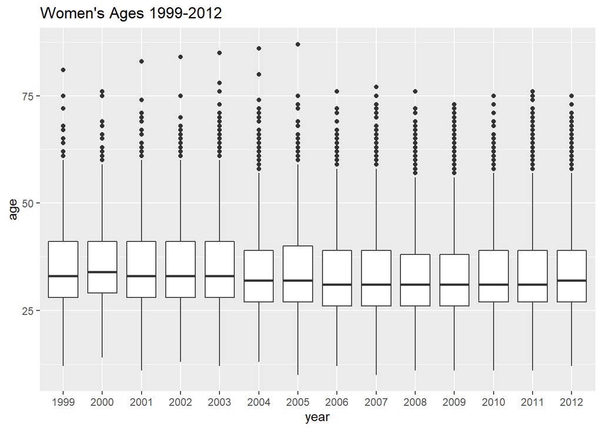

```r
# Look at womens box plots: filter out ages younger than 7
age %>% enframe(name = "year", value = "age") %>% unnest() %>% filter(age, age > 7) %>% ggplot(aes(year, age)) + geom_boxplot() + ggtitle("Women's Ages 1999-2012")
```

#### Age distribution for all years shows a right skewed distribution, with a mean age of 33.8. No clear evidence of a shift in runner age from 1999 to 2012.

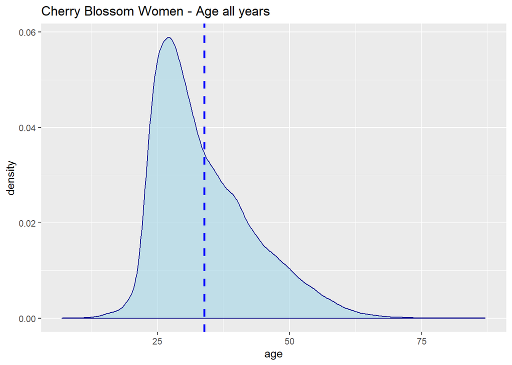

```r
# age distribution for all years
allWomen %>% ggplot() + geom_density(aes(x = age), alpha = 0.7,color="darkblue", fill="lightblue") + ggtitle("Cherry Blossom Women - Age all years") + geom_vline(aes(xintercept=mean(age)),
            color="blue", linetype="dashed", size=1)
```

```r
mean(allWomen$age)
```

```
## [1] 33.84925
```

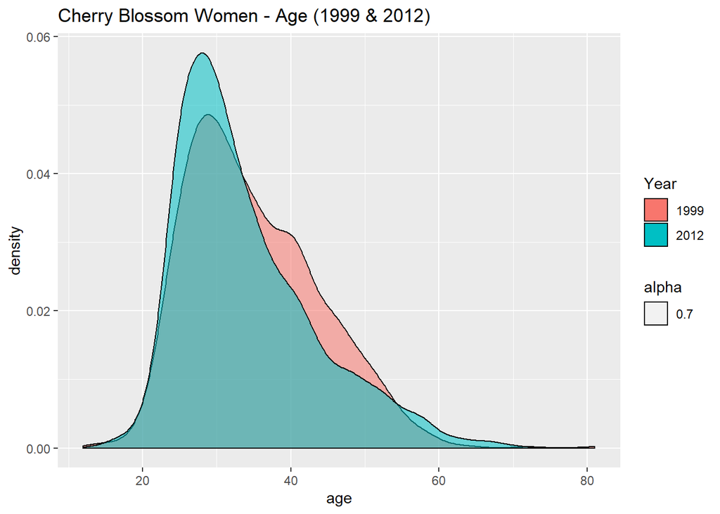

```r
list_of_values = c('1999','2012')
allWomen %>% filter(age > 7 & year == list_of_values) %>% ggplot() + geom_density(aes(x = age,group = factor(year), fill=factor(year), alpha = 0.7)) + ggtitle("Cherry Blossom Women - Age (1999 & 2012)") + labs(fill = "Year")
```

#### Run time distribution for all years shows a much more symmetric distribution.

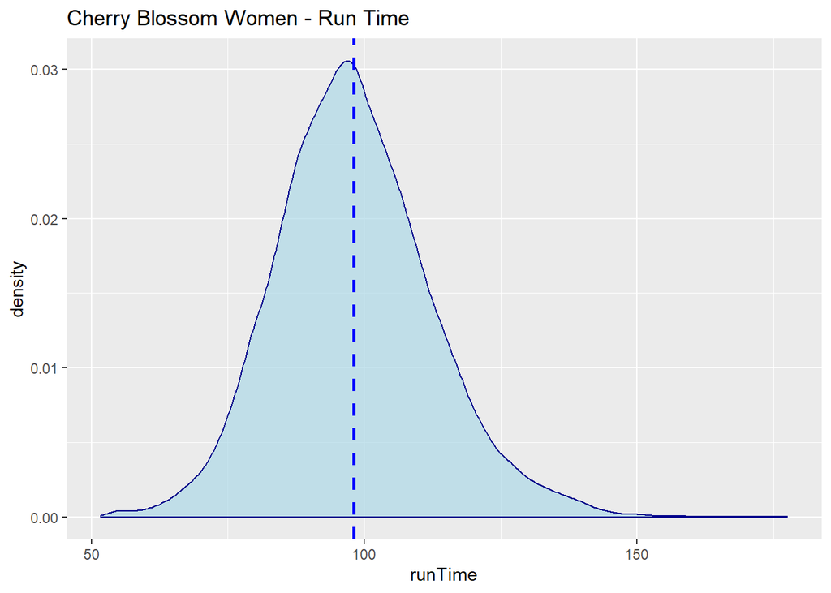

```r
# womens run time for all years
allWomen %>% ggplot() + geom_density(aes(x = runTime), alpha = 0.7,color="darkblue", fill="lightblue") + ggtitle("Cherry Blossom Women - Run Time") + geom_vline(aes(xintercept=mean(runTime)),
            color="blue", linetype="dashed", size=1)
```

#### The charts below highlight the following race insights: Race attendence has steadily increased over the years 1999-2012, average woman’s run time has increased, and average run time appears to increase as the ages get higher.

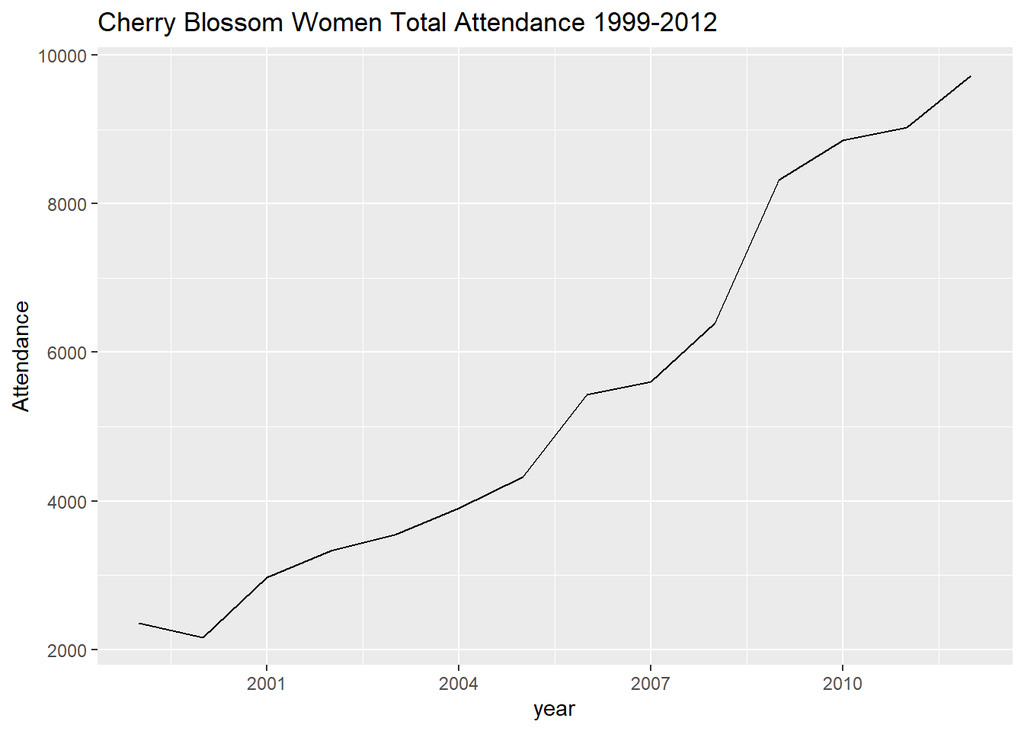

```r
# womens total attendance for all years
allWomen %>% group_by(year) %>% summarise(Attendance = n()) %>% na.omit %>% ggplot() + geom_line(aes( x = year, y = Attendance)) + ggtitle("Cherry Blossom Women Total Attendance 1999-2012")
```

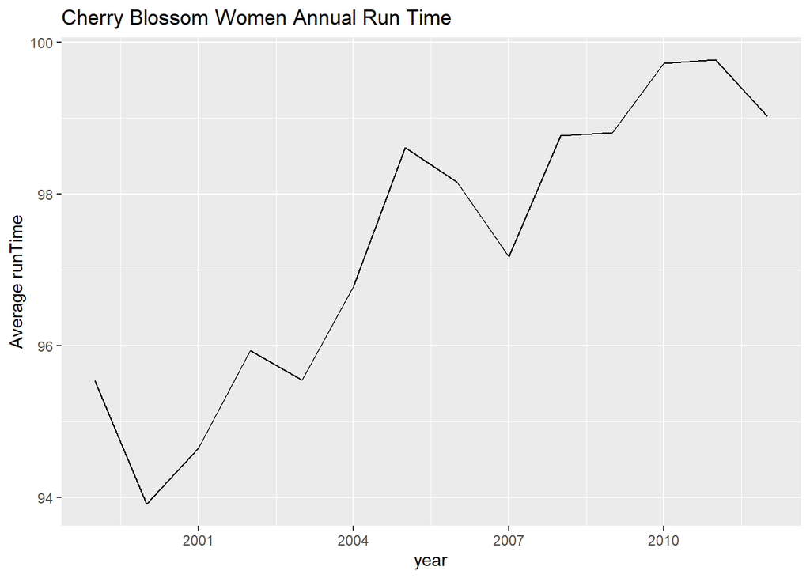

```r
# womens average run time for all years
allWomen %>% group_by(year) %>% summarise(`Average runTime` = mean(runTime, na.rm = T)) %>% ggplot() + geom_line(aes(x = year, y = `Average runTime`)) + ggtitle("Cherry Blossom Women Annual Run Time")
```

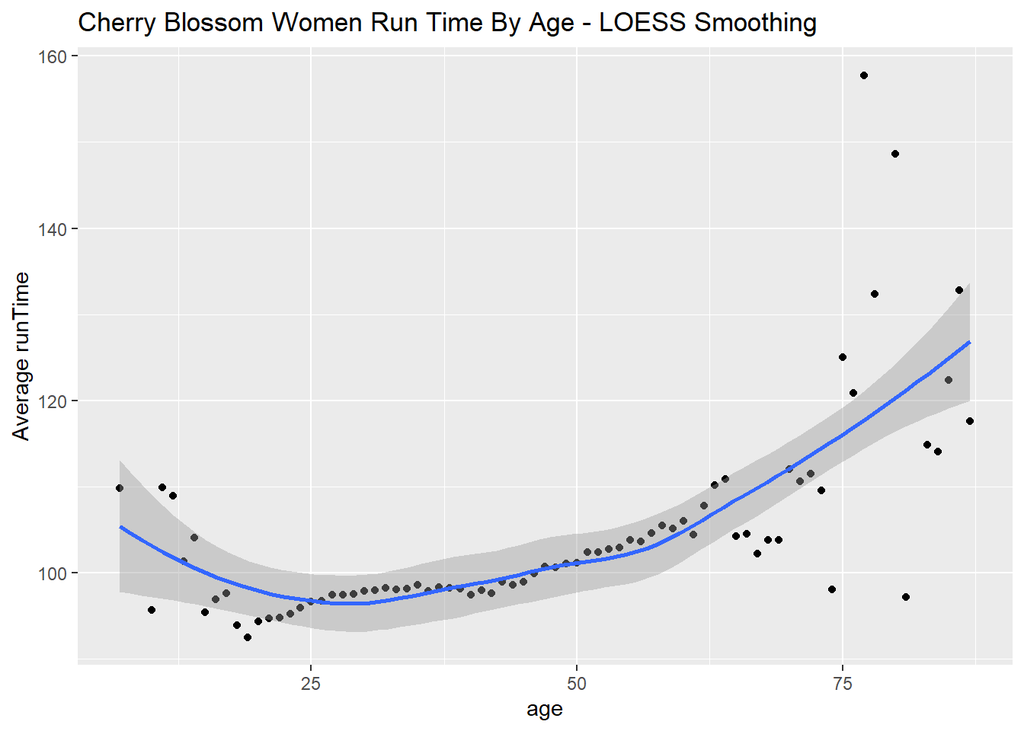

```r
# womens average run time by age
allWomen %>% group_by(age) %>% summarise(`Average runTime` = mean(runTime, na.rm = T)) %>% ggplot(aes(x = age, y = `Average runTime`)) + geom_point() + geom_smooth() + ggtitle("Cherry Blossom Women Run Time By Age - LOESS Smoothing")
```

#### We see some erratic behavior at the lower and higher ends of the age spectrum. Let’s examine the situation and search for changepoints in the data since we don’t know the exact age where this variation in average run time has occured. We’ll also use a bootstrapping method and include confidence intervals.

## Change-point Analysis

### Single Changepoint

```r
set.seed(1)
pw.model <- piecewise.linear(allWomen$age, allWomen$runTime, middle = 1, CI=TRUE, bootstrap.samples = 100, sig.level = 0.05)
pw.model
```

```
## [1] "Threshold alpha: 44.2765350072945"
## [1] ""
## [1] "Model coefficients: Beta[0], Beta[1], Beta[2]"
## (Intercept)           x           w
##  93.6254281   0.1232781   0.3004276
##       Change.Point Initial.Slope Slope.Change Second.Slope
## 2.5%      43.43277     0.1089299    0.2482896    0.3817829
## 97.5%     45.74647     0.1422588    0.3517079    0.4791656
```

#### Note a possible changepoint (threshold alpha) at age 44. Our model coefficients are also shown, as well as a confidence interval of our change point (43.4 - 45.7). Important to note here: “0” is not included in any of our confidence intervals, which is evidence to reject the null hypothesis, meaning there appears to be evidence of there being a changepoint in average run time at age 44.

### Testing for Multiple Changepoints.

```r
df = allWomen %>% group_by(age) %>% summarise(`Average runTime` = mean(runTime, na.rm = T))
df = data.frame(
  x = df$age,
  y = df$`Average runTime`)

fit_changepoint <- cpt.np(df$y, penalty = "CROPS", pen.value = c(25,100), method="PELT",
                       test.stat="empirical_distribution",class=TRUE,minseglen=2, nquantiles =4*log(length(df$x)))
```

```
## [1] "Maximum number of runs of algorithm = 4"
## [1] "Completed runs = 2"
## [1] "Completed runs = 3"
```

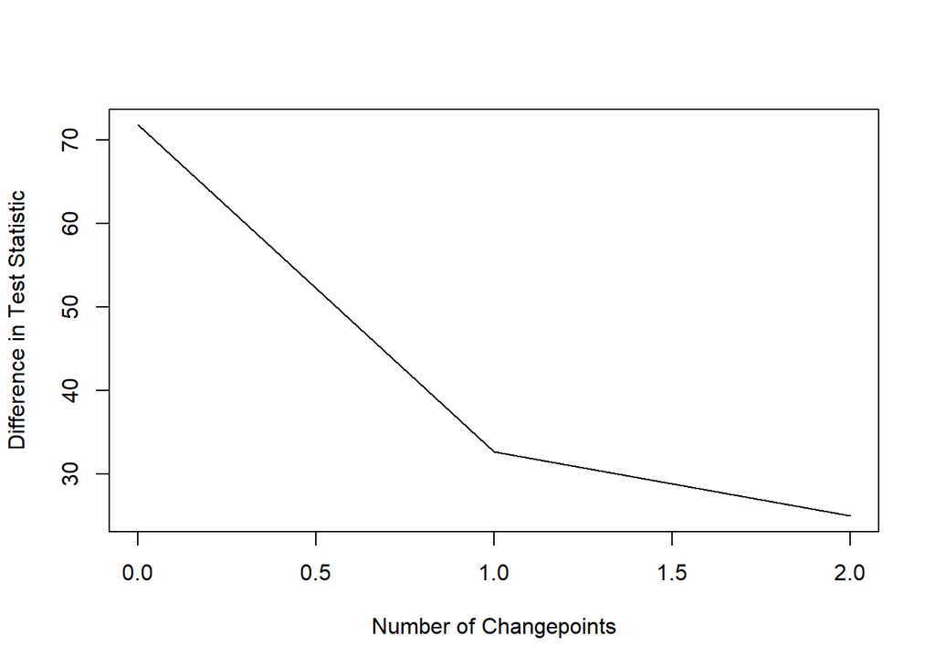

```r
plot(fit_changepoint, diagnostic = TRUE)
```

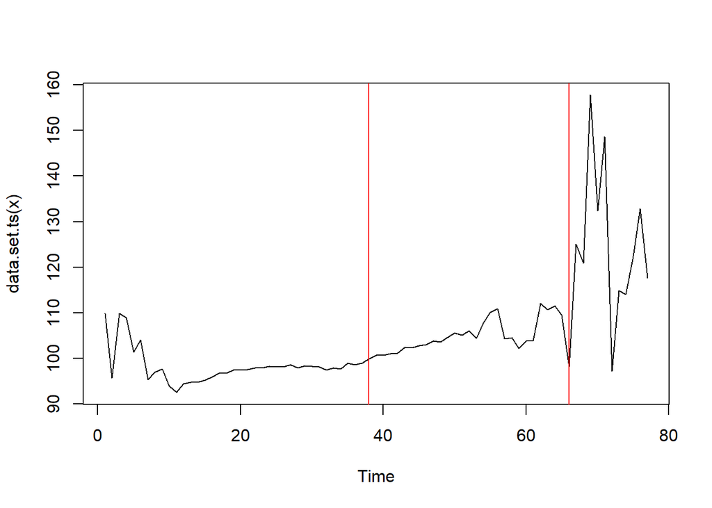

```r
plot(fit_changepoint, ncpts = 2)
```

```r
fit_changepoint
```

```
## Class 'cpt' : Changepoint Object
##        ~~   : S4 class containing 14 slots with names
##               cpts.full pen.value.full data.set cpttype method test.stat pen.type pen.value minseglen cpts ncpts.max param.est date version
##
## Created on  : Fri May 29 00:05:24 2020
##
## summary(.)  :
## ----------
## Created Using changepoint version 2.2.2
## Changepoint type      : Change in nonparametric (empirical_distribution)
## Method of analysis    : PELT
## Test Statistic  : empirical_distribution
## Type of penalty       : CROPS with value, 25 100
## Minimum Segment Length : 2
## Maximum no. of cpts   :
## Changepoint Locations :
## Range of segmentations:
##      [,1] [,2]
## [1,]   38   66
## [2,]   46   NA
## [3,]   NA   NA
##
##  For penalty values: 25 32.67409 71.79662
```